# REG+PCA+FA

Ivan

2022-11-09

## 1.1 Выбор данных

Выбран датасет измерений пульса людей до и после физической нагрузки.https://vincentarelbundock.github.io/Rdatasets/datasets.html Pulse.cv

## 1.2 Чтение данных

```r
df <- read.csv(file = "pulse.csv", header = TRUE, as.is = FALSE)
head(df)
```

```
##   X Active Rest Smoke Sex Exercise Hgt Wgt
## 1 1     97   78     0   1        1  63 119
## 2 2     82   68     1   0        3  70 225
## 3 3     88   62     0   0        3  72 175
## 4 4    106   74     0   0        3  72 170
## 5 5     78   63     0   1        3  67 125
## 6 6    109   65     0   0        3  74 188
```

Подготовка данных:

```r
df <- df[-1] #удаляем порядковый столбец
df$Smoke <- ifelse(df$Smoke==1, TRUE, FALSE) #True - курящие
df$Sex <- ifelse(df$Sex==1, TRUE, FALSE) #True - женщины
df$Hgt <- df$Hgt * 2.54 #Рост в сантиметры
df$Wgt <- df$Wgt * 0.45 #Вес в килограммы
head(df)
```

```
##   Active Rest Smoke   Sex Exercise    Hgt    Wgt
## 1     97   78 FALSE  TRUE        1 160.02  53.55
## 2     82   68  TRUE FALSE        3 177.80 101.25
## 3     88   62 FALSE FALSE        3 182.88  78.75
## 4    106   74 FALSE FALSE        3 182.88  76.50
## 5     78   63 FALSE  TRUE        3 170.18  56.25
## 6    109   65 FALSE FALSE        3 187.96  84.60
```

Просматривание пределов данных:

```r
summary(df)
```

```
##      Active           Rest          Smoke            Sex
##  Min.   : 51.0   Min.   : 43.00   Mode :logical   Mode :logical
##  1st Qu.: 79.0   1st Qu.: 62.00   FALSE:206       FALSE:122
##  Median : 88.5   Median : 68.00   TRUE :26        TRUE :110
##  Mean   : 91.3   Mean   : 68.35
##  3rd Qu.:102.0   3rd Qu.: 74.00
##  Max.   :154.0   Max.   :106.00
##     Exercise          Hgt             Wgt
##  Min.   :1.000   Min.   :152.4   Min.   : 45.90
##  1st Qu.:2.000   1st Qu.:165.1   1st Qu.: 60.75
##  Median :2.000   Median :172.7   Median : 67.50
##  Mean   :2.254   Mean   :173.3   Mean   : 71.06
##  3rd Qu.:3.000   3rd Qu.:180.3   3rd Qu.: 78.75
##  Max.   :3.000   Max.   :198.1   Max.   :117.00
```

## 1.3 Описание данных

Датасет содержит 232 индивида и 7 признаков:

Active - пульс после физической нагрузки

Rest - пульс в состояние покоя

Smoke - курящий или некурящий человек

Sex - пол

Exercise - сколько упражнений выполнил испытуемый

Hgt - рост

Wgt - вес

## 1.4 Определение типов признаков

```r
df %>% dplyr::summarize(dplyr::across(Active:Wgt, function(x) max(table(x))))
```

```
##   Active Rest Smoke Sex Exercise Hgt Wgt
## 1     16   15   206 122      100  31  20
```

Из мод и из смысла данных:

Active - количественный непрерывный признак

Rest - количественный непрерывный признак

Smoke - качественный признак

Sex - качественный признак

Exercise - количественный дискретный признак

Hgt - количественный дискретный признак

Wgt - количественный непрерывный признак

## 1.5 Порядковые признаки

В данном датасете таких данных нет

## 1.6 Pairs

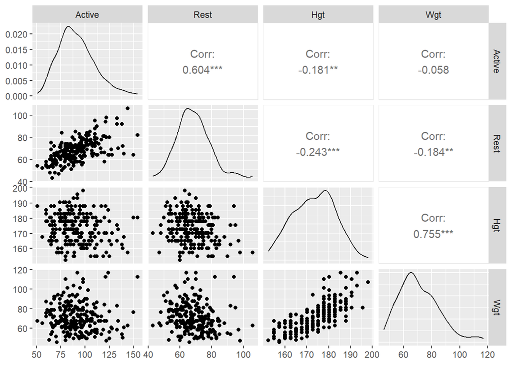

```r
num_col <- c("Active","Rest","Hgt", "Wgt")
f <- ggpairs(na.omit(df), columns = num_col,  diag = list(diag = list(continuous = "densityDiag", discrete = "blankDiag", na = "blankDiag")), cardinality_threshold=NULL)
print(f)
```

## 1.7 Логарифмирование

Все распределения похожи на нормальныt - логарифмировать нет необходимости

## 1.8-10 Outliers, matrix plot для подгрупп, объяснение неоднородностей

Для поиска выбросов построим графики для отдельных групп:

Мужчины и женщины:

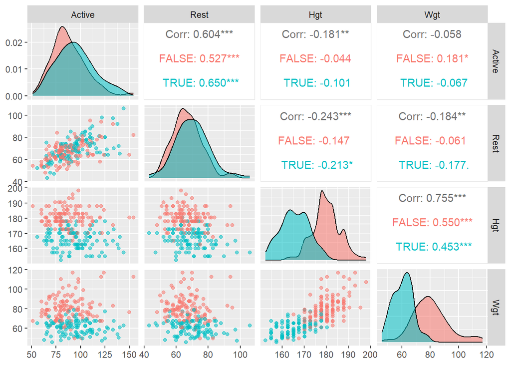

```r
f <- ggpairs(df, columns = num_col,  diag = list(diag = list(continuous = "densityDiag", discrete = "blankDiag", na = "blankDiag")), cardinality_threshold=NULL, mapping = aes(color = df$Sex, alpha = 0.8))
print(f)
```

Курящие и некурящие:

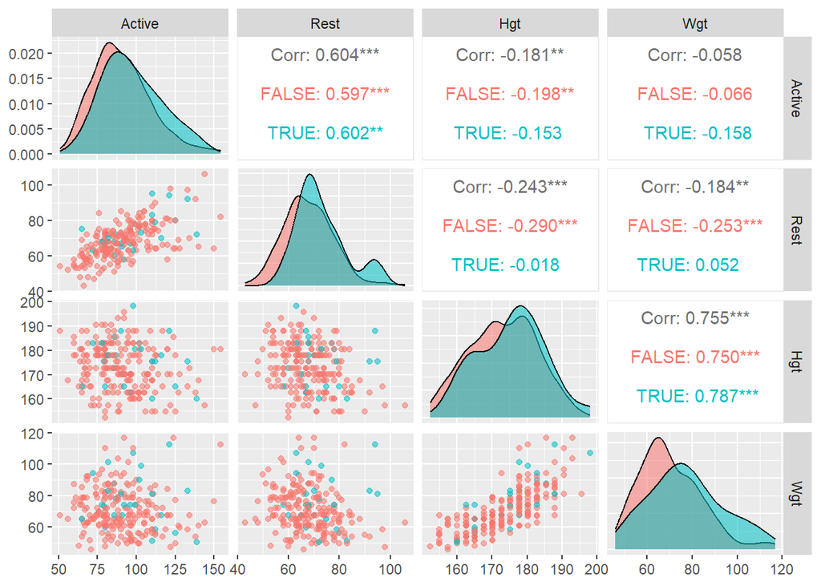

```r
f <- ggpairs(df, columns = num_col,  diag = list(diag = list(continuous = "densityDiag", discrete = "blankDiag", na = "blankDiag")), cardinality_threshold=NULL, mapping = aes(color = df$Smoke, alpha = 0.8))
print(f)
```

Удаляем выбросы:

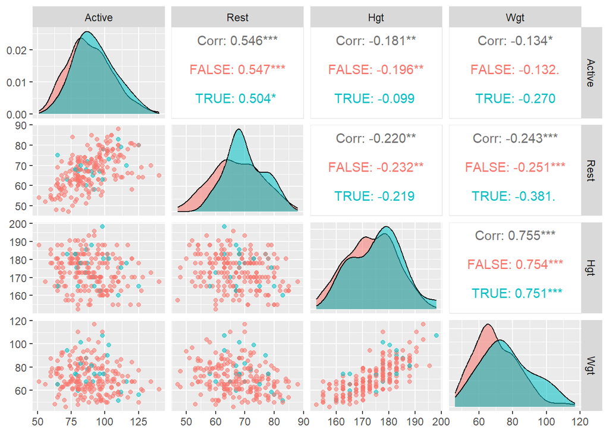

```r
correctdf <- df
correctdf[7,] <- NA
correctdf[26,] <- NA
correctdf[48,] <- NA
correctdf[180,] <- NA
correctdf[67,] <- NA
correctdf[140,] <- NA
correctdf[162,] <- NA
correctdf[176,] <- NA
correctdf[74,] <- NA
correctdf[183,] <- NA
correctdf[198,] <- NA
correctdf[179,] <- NA
correctdf[217,] <- NA
correctdf <- na.omit(correctdf)

ggpairs(correctdf, columns = num_col,  diag = list(diag = list(continuous = "densityDiag", discrete = "blankDiag", na = "blankDiag")), cardinality_threshold=NULL, mapping = aes(color = correctdf$Smoke, alpha = 0.8))
```

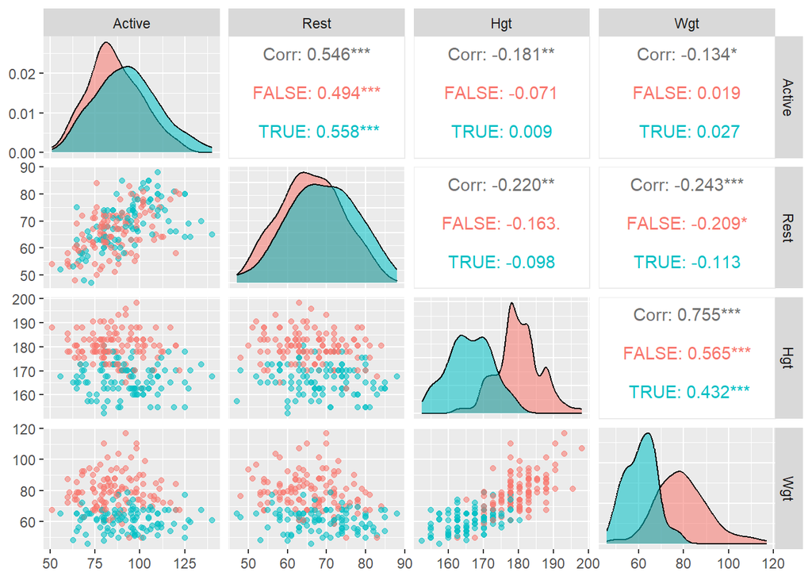

```r
ggpairs(correctdf, columns = num_col,  diag = list(diag = list(continuous = "densityDiag", discrete = "blankDiag", na = "blankDiag")), cardinality_threshold=NULL, mapping = aes(color = correctdf$Sex, alpha = 0.8))
```

Видим ленейную зависимость между весом и ростом и между пульсом до и после физической нагрузки

Видим неоднородности между остальными признаками попарно - объясняются половым фактором

## 1.11 Descriptive statistics

```r
summary(correctdf)
```

```
##      Active           Rest         Smoke            Sex
##  Min.   : 51.0   Min.   :47.00   Mode :logical   Mode :logical
##  1st Qu.: 79.0   1st Qu.:62.00   FALSE:197       FALSE:116
##  Median : 88.0   Median :67.00   TRUE :22        TRUE :103
##  Mean   : 89.2   Mean   :67.43
##  3rd Qu.: 99.0   3rd Qu.:74.00
##  Max.   :140.0   Max.   :88.00
##     Exercise          Hgt             Wgt
##  Min.   :1.000   Min.   :152.4   Min.   : 45.90
##  1st Qu.:2.000   1st Qu.:166.4   1st Qu.: 60.75
##  Median :2.000   Median :172.7   Median : 67.50
##  Mean   :2.306   Mean   :173.5   Mean   : 70.83
##  3rd Qu.:3.000   3rd Qu.:180.3   3rd Qu.: 78.75
##  Max.   :3.000   Max.   :198.1   Max.   :117.00
```

```r
dplyr::summarize(correctdf, across(num_col, list(kurtosis = kurtosis, skewness = skewness)))
```

```
##   Active_kurtosis Active_skewness Rest_kurtosis Rest_skewness Hgt_kurtosis
## 1        2.877732       0.3746615      2.461221   -0.00219902     2.417675
##   Hgt_skewness Wgt_kurtosis Wgt_skewness
## 1  -0.03229696     3.282206    0.6444638
```

## 2.1-2 Выбор категорирующей переменной и Boxplot

Избавимся от курящих индивидов:

```r
noSmokedf <- correctdf %>% filter(Smoke == FALSE)

useDf <- noSmokedf[,c("Active", "Rest", "Wgt", "Hgt", "Sex")]
```

Группировка по полу:

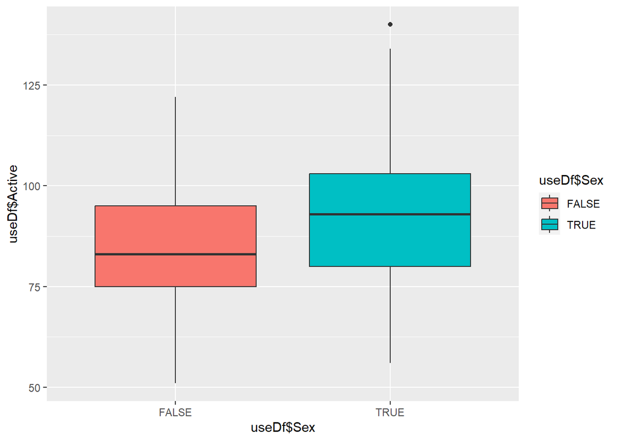

```r
ggplot(useDf, aes(x = useDf$Sex, y = useDf$Active, fill = useDf$Sex)) + geom_boxplot()
```

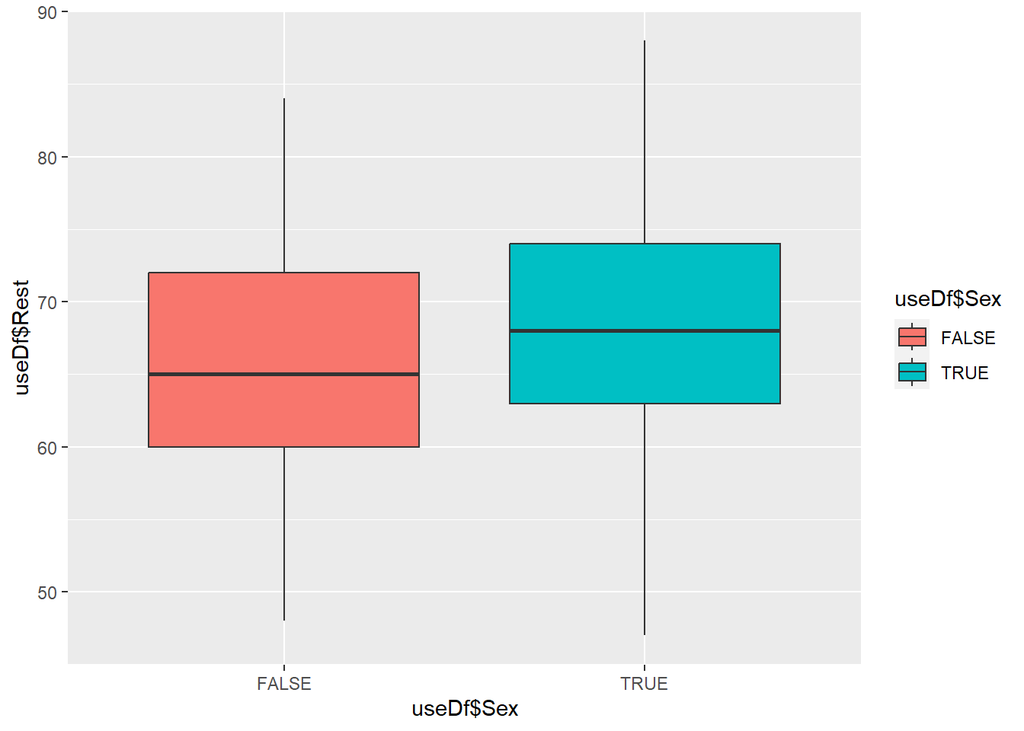

```r
ggplot(useDf, aes(x = useDf$Sex, y = useDf$Rest, fill = useDf$Sex)) + geom_boxplot()
```

## 2.3 Проверка нормальности

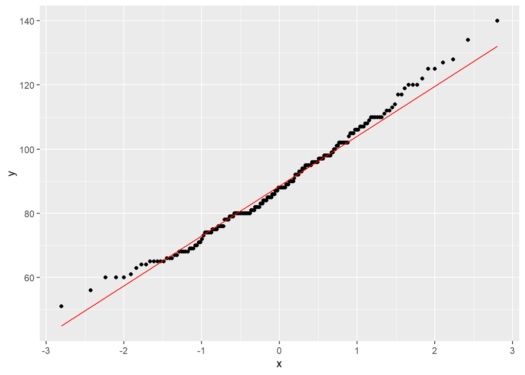

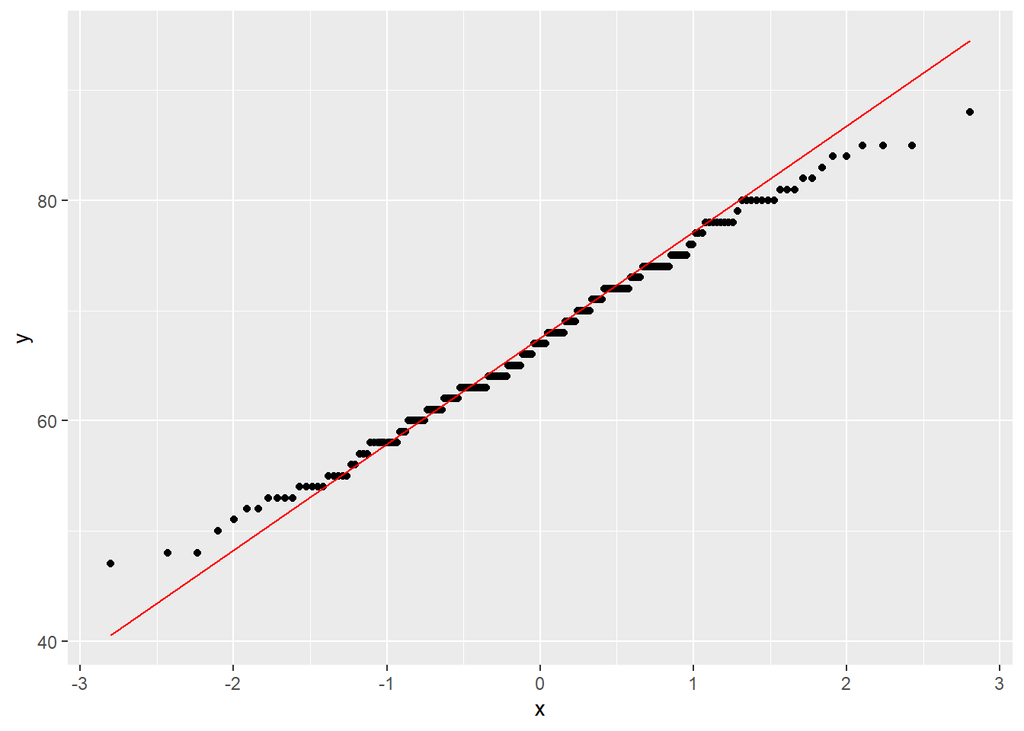

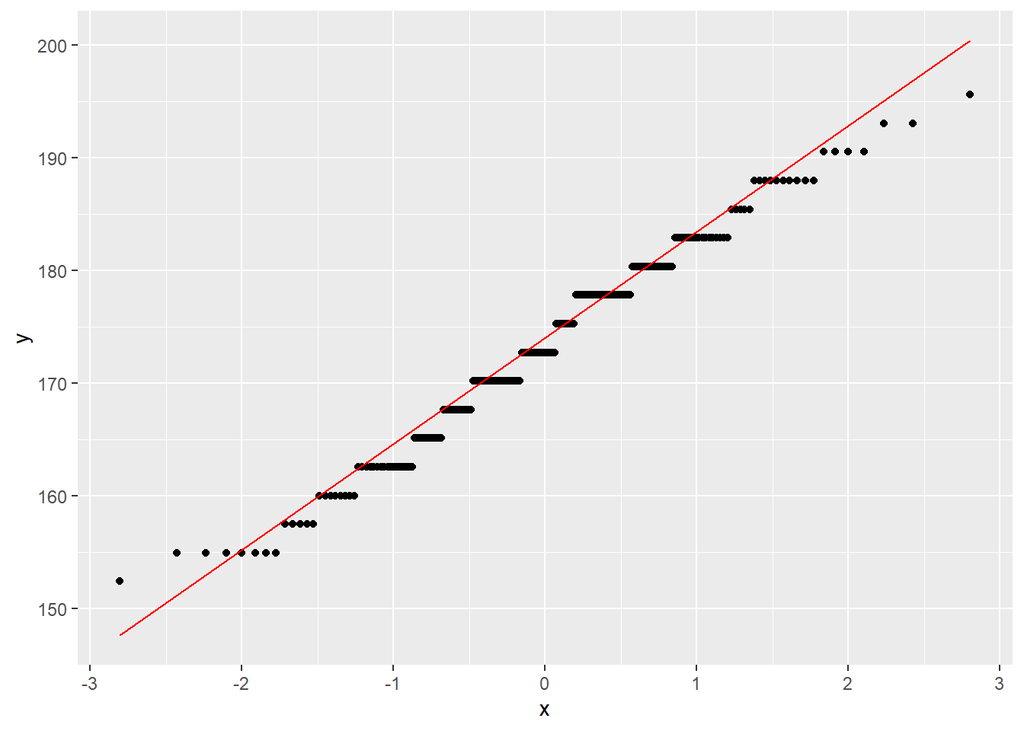

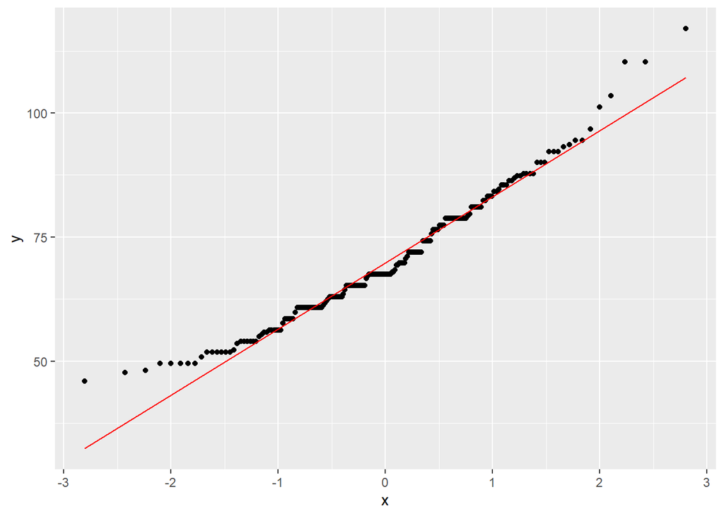

```r
QQplot <- function(data, column) ggplot(data, aes(sample = data[, column])) + stat_qq() + stat_qq_line(colour = "red")

lapply(names(useDf[, num_col]), function(x) QQplot(noSmokedf, x))
```

Распределния всех факторов близки к нормальному вблизи средних значений.

## 2.4 t-test для обнаружения разницы в среднем

```r
t.test(Active ~ Sex, data = useDf)
```

```
##
##  Welch Two Sample t-test
##
## data:  Active by Sex
## t = -3.0249, df = 188.58, p-value = 0.002834
## alternative hypothesis: true difference in means between group FALSE and group TRUE is not equal to 0
## 95 percent confidence interval:
##  -11.587431  -2.439814
## sample estimates:
## mean in group FALSE  mean in group TRUE
##            85.47059            92.48421
```

```r
t.test(Rest ~ Sex, data = useDf)
```

```
##
##  Welch Two Sample t-test
##
## data:  Rest by Sex
## t = -2.5271, df = 191.83, p-value = 0.01231
## alternative hypothesis: true difference in means between group FALSE and group TRUE is not equal to 0
## 95 percent confidence interval:
##  -5.4852322 -0.6761713
## sample estimates:
## mean in group FALSE  mean in group TRUE
##            65.66667            68.74737
```

```r
t.test(Hgt ~ Sex, data = useDf)
```

```
##
##  Welch Two Sample t-test
##
## data:  Hgt by Sex
## t = 15.896, df = 193.21, p-value < 2.2e-16
## alternative hypothesis: true difference in means between group FALSE and group TRUE is not equal to 0
## 95 percent confidence interval:
##  12.29109 15.77316
## sample estimates:
## mean in group FALSE  mean in group TRUE
##            180.0412            166.0091
```

```r
t.test(Wgt ~ Sex, data = useDf)
```

```
##
##  Welch Two Sample t-test
##
## data:  Wgt by Sex
## t = 13.177, df = 166.19, p-value < 2.2e-16
## alternative hypothesis: true difference in means between group FALSE and group TRUE is not equal to 0
## 95 percent confidence interval:
##  15.22578 20.59264
## sample estimates:
## mean in group FALSE  mean in group TRUE
##            78.82500            60.91579
```

## 2.5 Критерий Колмогорова-Смирнова для сравнения по сдвигу

```r
ks.test(Active ~ Sex, data = useDf)
```

```
##
##  Exact two-sample Kolmogorov-Smirnov test
##
## data:  Active by Sex
## D = 0.2129, p-value = 0.01379
## alternative hypothesis: two-sided
```

```r
ks.test(Rest ~ Sex, data = useDf)
```

```
##
##  Exact two-sample Kolmogorov-Smirnov test
##
## data:  Rest by Sex
## D = 0.1807, p-value = 0.0428
## alternative hypothesis: two-sided
```

```r
ks.test(Hgt ~ Sex, data = useDf)
```

```
##
##  Exact two-sample Kolmogorov-Smirnov test
##
## data:  Hgt by Sex
## D = 0.74912, p-value = 7.083e-14
## alternative hypothesis: two-sided
```

```r
ks.test(Wgt ~ Sex, data = useDf)
```

```
##
##  Exact two-sample Kolmogorov-Smirnov test
##
## data:  Wgt by Sex
## D = 0.73932, p-value = 7.083e-14
## alternative hypothesis: two-sided
```

## 3.1 Корреляционный анализ

Стандартизуем и нормируем признаки:

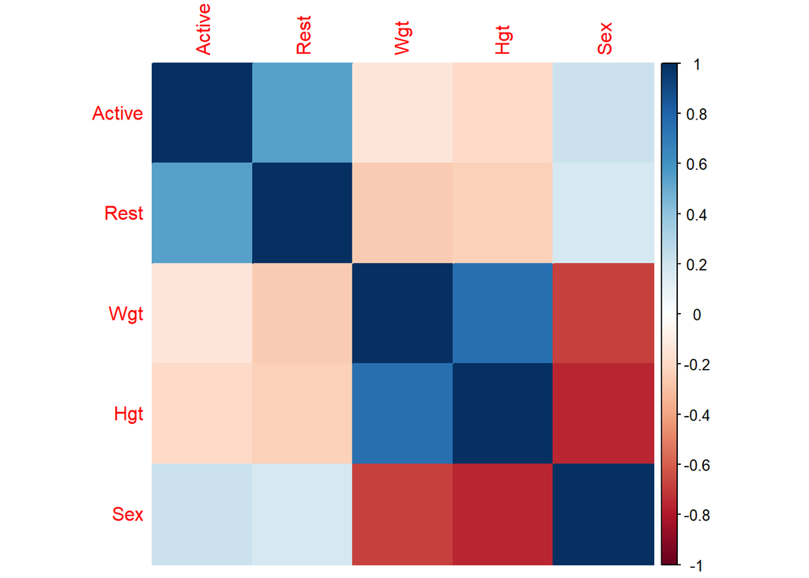

```r
m = cor(useDf)
corrplot(m, method = 'color')
```

Корреляционные коэффициенты Пирсона:

```r
rcorr(as.matrix(useDf), type="pearson")
```

```
##        Active  Rest   Wgt   Hgt   Sex
## Active   1.00  0.55 -0.13 -0.20  0.21
## Rest     0.55  1.00 -0.25 -0.23  0.18
## Wgt     -0.13 -0.25  1.00  0.75 -0.68
## Hgt     -0.20 -0.23  0.75  1.00 -0.75
## Sex      0.21  0.18 -0.68 -0.75  1.00
##
## n= 197
##
##
## P
##        Active Rest   Wgt    Hgt    Sex
## Active        0.0000 0.0649 0.0057 0.0027
## Rest   0.0000        0.0004 0.0011 0.0121
## Wgt    0.0649 0.0004        0.0000 0.0000
## Hgt    0.0057 0.0011 0.0000        0.0000
## Sex    0.0027 0.0121 0.0000 0.0000
```

Корреляционные коэффициенты Спирмена:

```r
rcorr(as.matrix(useDf), type="spearman")
```

```
##        Active  Rest   Wgt   Hgt   Sex
## Active   1.00  0.59 -0.14 -0.21  0.21
## Rest     0.59  1.00 -0.26 -0.23  0.18
## Wgt     -0.14 -0.26  1.00  0.77 -0.73
## Hgt     -0.21 -0.23  0.77  1.00 -0.78
## Sex      0.21  0.18 -0.73 -0.78  1.00
##
## n= 197
##
##
## P
##        Active Rest   Wgt    Hgt    Sex
## Active        0.0000 0.0425 0.0029 0.0034
## Rest   0.0000        0.0002 0.0009 0.0122
## Wgt    0.0425 0.0002        0.0000 0.0000
## Hgt    0.0029 0.0009 0.0000        0.0000
## Sex    0.0034 0.0122 0.0000 0.0000
```

## 3.2 Регрессия

```r
library(lm.beta)
lm.df.oecd <- lm.beta(lm(data = useDf, Active ~  Rest + Hgt + Wgt + Sex ))
summary(lm.df.oecd)
```

```
##
## Call:
## lm(formula = Active ~ Rest + Hgt + Wgt + Sex, data = useDf)
##
## Residuals:
##     Min      1Q  Median      3Q     Max
## -27.425  -8.945  -1.921   6.687  51.638
##
## Coefficients:
##             Estimate Standardized Std. Error t value Pr(>|t|)
## (Intercept) 19.84139           NA   31.57632   0.628   0.5305
## Rest         1.03927      0.54374    0.11725   8.864 5.27e-16 ***
## Hgt         -0.11604     -0.06565    0.18398  -0.631   0.5290
## Wgt          0.23186      0.18502    0.11796   1.966   0.0508 .
## SexTRUE      6.33602      0.19199    3.07077   2.063   0.0404 *
## ---
## Signif. codes:  0 '***' 0.001 '**' 0.01 '*' 0.05 '.' 0.1 ' ' 1
##
## Residual standard error: 13.71 on 192 degrees of freedom
## Multiple R-squared:  0.3266, Adjusted R-squared:  0.3125
## F-statistic: 23.28 on 4 and 192 DF,  p-value: 1.064e-15
```

Улучшим исходную модель по AIC:

```r
lm.df.oecd.full <- lm.beta(lm(data = useDf, Active ~  Rest + Hgt + Wgt + Sex ))
stepAIC(lm.df.oecd.full, direction = "backward")
```

```
## Start:  AIC=1036.4
## Active ~ Rest + Hgt + Wgt + Sex
##
##        Df Sum of Sq   RSS    AIC
## - Hgt   1      74.7 36150 1034.8
## <none>              36075 1036.4
## - Wgt   1     725.9 36801 1038.3
## - Sex   1     799.9 36875 1038.7
## - Rest  1   14761.8 50837 1102.0
##
## Step:  AIC=1034.81
## Active ~ Rest + Wgt + Sex
##
##        Df Sum of Sq   RSS    AIC
## <none>              36150 1034.8
## - Wgt   1     678.0 36828 1036.5
## - Sex   1    1407.7 37558 1040.3
## - Rest  1   14982.7 51133 1101.1
```

```
##
## Call:
## lm(formula = Active ~ Rest + Wgt + Sex, data = useDf)
##
## Coefficients:
## (Intercept)         Rest          Wgt      SexTRUE
##      1.4753       1.0444       0.1955       7.2972
```

```r
lm.df.oecd <- lm.beta(lm(data = useDf, Active ~  Rest + Wgt + Sex ))
summary(lm.df.oecd)
```

```
##
## Call:
## lm(formula = Active ~ Rest + Wgt + Sex, data = useDf)
##
## Residuals:
##     Min      1Q  Median      3Q     Max
## -26.845  -9.413  -2.222   6.675  51.462
##
## Coefficients:
##             Estimate Standardized Std. Error t value Pr(>|t|)
## (Intercept)   1.4753           NA    12.1924   0.121  0.90381
## Rest          1.0444       0.5464     0.1168   8.944 3.08e-16 ***
## Wgt           0.1955       0.1560     0.1028   1.903  0.05859 .
## SexTRUE       7.2972       0.2211     2.6618   2.741  0.00669 **
## ---
## Signif. codes:  0 '***' 0.001 '**' 0.01 '*' 0.05 '.' 0.1 ' ' 1
##
## Residual standard error: 13.69 on 193 degrees of freedom
## Multiple R-squared:  0.3252, Adjusted R-squared:  0.3147
## F-statistic:    31 on 3 and 193 DF,  p-value: < 2.2e-16
```

```r
PulsePred <- data.frame(Rest = 60, Hgt = 170, Wgt = 55, Sex = TRUE )
predict.lm(lm.df.oecd, PulsePred, interval = "prediction")
```

```
##        fit     lwr      upr
## 1 82.19154 54.9394 109.4437
```

```r
predict.lm(lm.df.oecd, PulsePred, interval = "confidence")
```

```
##        fit     lwr      upr
## 1 82.19154 78.4448 85.93829
```

## 4. АГК

Для анализа главных компанент, возьмем только индивидов с женским полом:

```r
useDf <- useDf %>% filter(Sex == TRUE)

PCADf <- useDf[,c("Active", "Rest", "Wgt", "Hgt")]
```

Воспользуемся пакетами FactoMineR и factoextra для проведения и демонстрации результатов АГК:

```r
library("FactoMineR")
```

```r
result.pca = PCA(PCADf, scale.unit=TRUE, ncp=4, graph=F)
```

```r
result.pca$eig
```

```
##        eigenvalue percentage of variance cumulative percentage of variance
## comp 1  1.5947324               39.86831                          39.86831
## comp 2  1.4217031               35.54258                          75.41089
## comp 3  0.5611769               14.02942                          89.44031
## comp 4  0.4223877               10.55969                         100.00000
```

eigenvalue - значения $\lambda_i$ (дисперсии) собственные числа для $i-$той ГК

percentage of variance (дольная дисперсия) - сколько процентов данных описывается $i-$той ГК

cumulative percentage of variance (накопительная дисперсия) - сколько процентов данных описывается текщими ГК

Построим график “каменистой осыпи” для полученных ГК (иллюстрация полученных на предыдущем шаге значений, “каменистая осыпь” используется для определения числа необходимых ГК, но в случае с 4 ГК необходимо использовать другой метод - например, использовать только те ГК, которые мы можем как-то интерпретировать)

```r
library("factoextra")
```

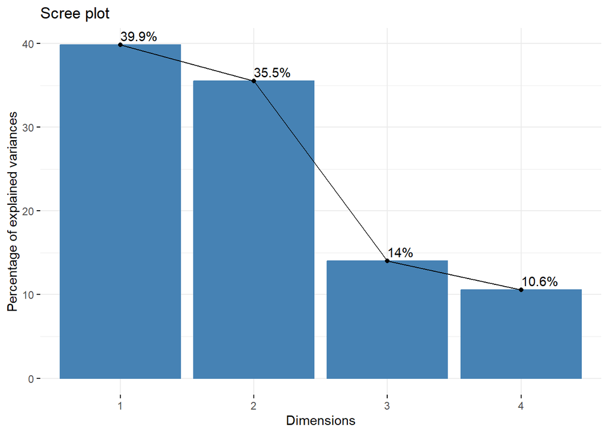

```r
fviz_eig(result.pca, addlabels = TRUE)
```

Вывод собственных векторов $U_i$:

```r
result.pca$svd$V
```

```
##            [,1]      [,2]       [,3]        [,4]
## [1,]  0.6113016 0.3713682 -0.1106514 -0.69003788
## [2,]  0.6651008 0.2333940  0.1816482  0.68569093
## [3,] -0.2721846 0.6547393 -0.6703617  0.21873994
## [4,] -0.3314615 0.6155724  0.7108976 -0.07634472
```

Так как $Z_i=\textbf{X}U_i$, значит $Z_i$ линейная комбинация признаков, с коэффициентами, взятыми из $U_i$. Значит, ГК - это ортоганальные между собой линейные комбинации исходных признаков, так как $U_i$ - ортонормированный базис столбцов (признаков).

На основе этого интерпретируем первые 2 ГК:

1 - Разница между средним пульсом и комплекцией тела

2 - Суммарный вклад комплекции человека и его пульса в покое и после нагрузки

Вывод координат индивидов $z_{ij}=<x_i,U_j>_1$ - $j$-ая координата $i$-того индивида в базисе новых признаков. При $j$ принимающим значения $1$ и $2$, получаем координаты индивидов в базисе 1 и 2 ГК:

```r
result.ind <- get_pca_ind(result.pca)
head(result.ind$coord)
```

```
##        Dim.1      Dim.2      Dim.3       Dim.4
## 1  1.4757109 -0.9451370  0.1957060  0.38311606
## 2 -0.9950802 -0.5001927  0.9038447 -0.06346438
## 3 -1.1389248 -1.7104225  0.7304644 -0.13384216
## 4  1.3396078  1.0811185 -0.1843958 -2.24411587
## 5  1.7877306  0.5642064 -0.3393691  0.87706267
## 6  0.9684058  2.2264343 -0.1179557 -1.45679013
```

Вывод координат признаков $f_{ij}=<X_i,V_j>_2$ - $j$-ая координата $i$-того признака в базисе новых признаков. При $j$ принимающим значения $1$ и $2$, получаем координаты старых признаков в базисе 1 и 2 ГК:

```r
var <- get_pca_var(result.pca)
var$coord
```

```
##             Dim.1     Dim.2       Dim.3       Dim.4
## Active  0.7719683 0.4428015 -0.08289085 -0.44846499
## Rest    0.8399074 0.2782878  0.13607584  0.44563985
## Wgt    -0.3437221 0.7806796 -0.50217965  0.14216206
## Hgt    -0.4185786 0.7339790  0.53254573 -0.04961747
```

Выведем график, отражающий то, как хорошо исходный признак описывается первыми двумя ГК:

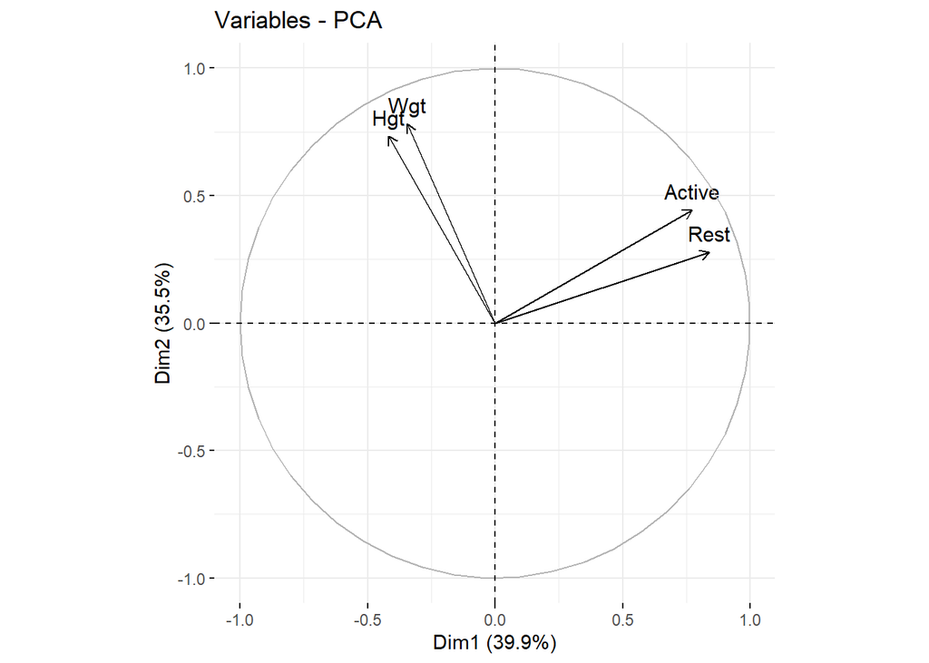

```r
fviz_pca_var(result.pca)
```

Коорданты векторов признаков соотвествуют $f_{ij}=<X_i,V_j>_2$, где $j$-ая координата $i$-того признака в базисе новых признаков

Интерпритировать это можно так:

Так как АГК построенно по корреляционной матрице (данные центрированы и нормированы), то косинус угла наклона между вектором изначального признака и плоскостью первых двух ГК можно считать корреляцией (формулы совпадут).

На приведенном выше графике длина вектора $i$-того изначальным признака соотвествует значению множественной корреляции $i$-того изначального признака с первыми двумя ГК, координаты $(x,y)$ векторов признаков на данном графике соотвествуют корреляциям с 1 и 2 ГК соответственно.

Для илюстрации того, как изначальные признаки описываются ГК выведем матрицу соответсвия косинуса угла в квадрате между $i$-тым изначальным признаком и $i$-той ГК (по сути выводим корреляции).

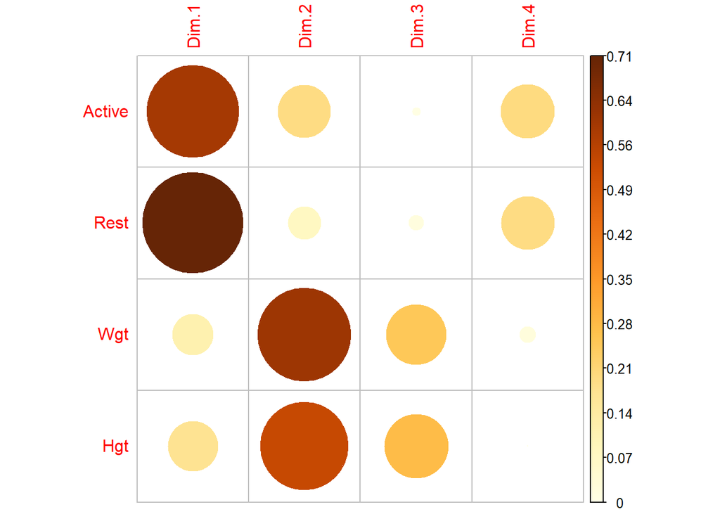

```r
library("corrplot")
corrplot(var$cos2, is.corr=FALSE)
```

Построим BiPlot из проекций индивидов в координаты 1 и 2 ГК (Ось абсцисс - первая ГК ($Z_1$), Ось ординат - вторая ГК ($Z_2$))

Чтобы посчитать, как хорошо индивид описывается плоскостью, образованной первыми двумя ГК, необходимо посчитать косинус угла между плоскостью и индивидом. Очевидно, что индивиды, перпендикулярные плоскости, плохо описываются этой плоскость. Для индивидов, перпендикулярных плоскость косинус угла будет 0. Косинус берется в квадрае, чтобы сравнивать положительные значения

Построим график, показывающий проекции индивидов на плоскость первых двух ГК ($z_{ij}=<x_i,U_j>_1$ - $j$-ая координата $i$-того индивида в базисе новых признаков. При $j$ принимающим значения $1$ и $2$, получаем координаты индивидов в базисе 1 и 2 ГК):

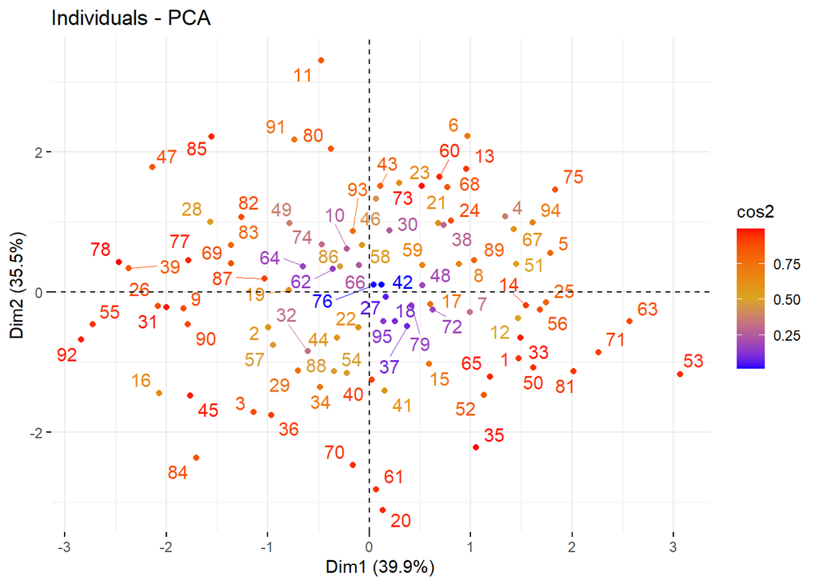

```r
fviz_pca_ind(result.pca,
             col.ind = "cos2",
             gradient.cols = c("#0000FF", "#DAA520", "#FF0000"),
             repel = TRUE
             )
```

Соотвественно, индивиды, отмеченные синим цветом, хуже описываются первыми двумя ГК, чем индивиды, отмеченные красным цветом.

Далее построим график проекций индивидов и проекций изначальных признаков на плоскость первых двух ГК(Ось абсцисс - первая ГК ($Z_1$), Ось ординат - вторая ГК ($Z_2$)

$z_{ij}=<x_i,U_j>_1$ - $j$-ая координата $i$-того индивида в базисе новых признаков. При $j$ принимающим значения $1$ и $2$, получаем координаты индивидов в базисе 1 и 2 ГК

$p_{ij} = e_i \cdot ( U_1^j ... U_p^j)^T$ - $j$-ая координата $i$-того старого признака соответственно ($e_i$ - вектор строка из нулей, с единицей на позиции, соотвествующей $i$)

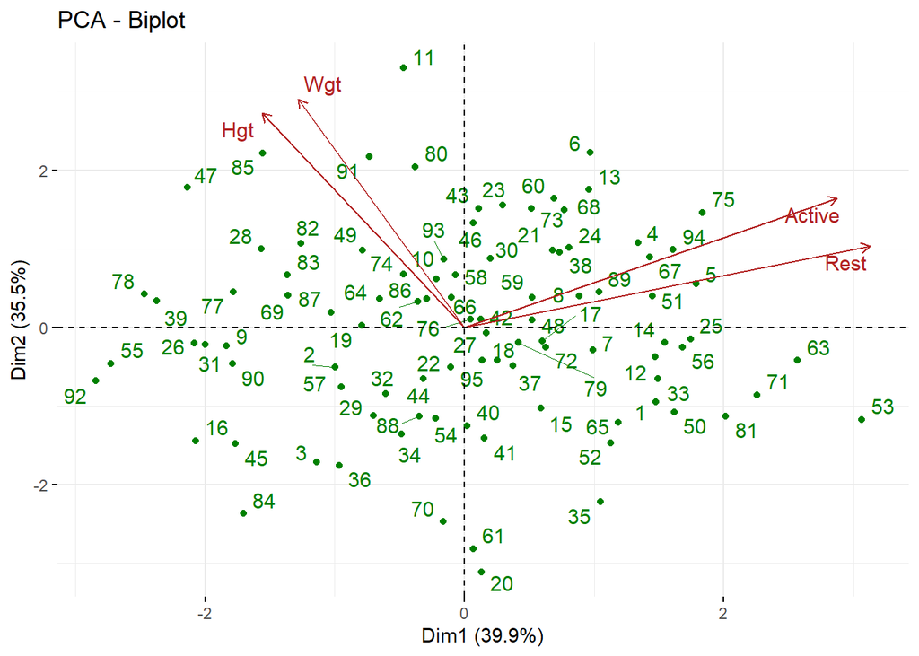

```r
fviz_pca_biplot(result.pca, repel = TRUE,
                col.var = "#B22222",
                col.ind = "#008000"
                )
```

Разберемся с характеристиками аутлаеров (принимаем во внимание, что признаки центрированы и стандартизованы)(смысл 1 ГК: справа от 0 - большое среднее значение пульса - комплеция)(смысл 2 ГК: сверху от 0: большая комплекция человека + учет среднего пульса):

53 индивид - имеет большое среднее значение пульса (по 1 ГК), имеет комплецию ниже среднего (по 2 ГК)

11 индивид - имеет среднее значение пульса ниже, чем среднее по выборки (по 1 ГК), имеет большую комплецию (по 2 ГК)

## 5. ФА

Спевра еще раз вглянем на корреляционную матрицу:

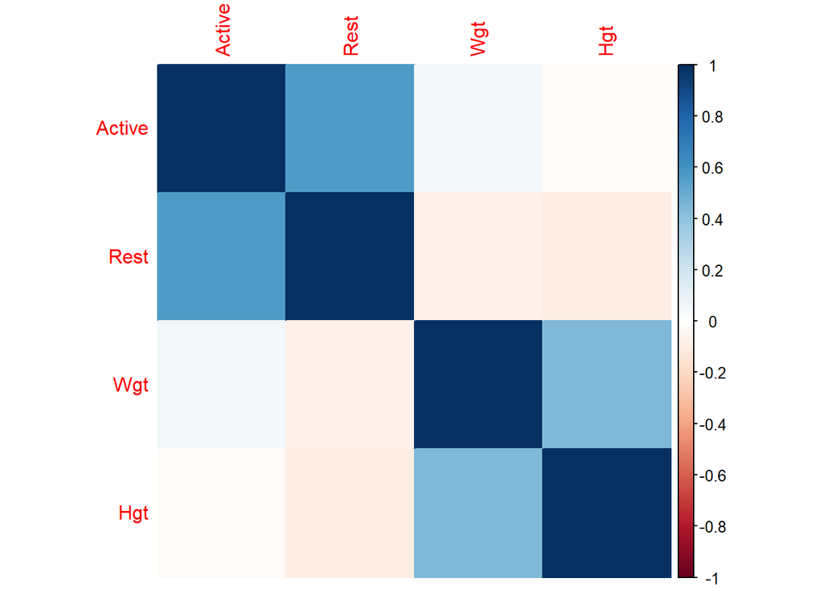

```r
m = cor(PCADf)
corrplot(m, method = 'color')
```

Видим, что сильно коррелирую друг с другом две пары признаков: пульс до и после физической нагрузки, и рост с весом.

Проведем тест Кайзера-Мейера-Олкина:

```r
library(psych)
library(reshape2)
KMO(m)
```

```
## Kaiser-Meyer-Olkin factor adequacy
## Call: KMO(r = m)
## Overall MSA =  0.5
## MSA for each item =
## Active   Rest    Wgt    Hgt
##   0.49   0.50   0.49   0.51
```

Показатель MSA - показатель адекватности всей выборки для факторого анализа

Показатели MSAi - показатели адекватности для каждого признака для факторного анализа

Теперь проведем тест сферичности Бартлета (проверяется гипотеза о том, что корреляционная матрицы единичная):

```r
cortest.bartlett(PCADf)
```

```
## R was not square, finding R from data
```

```
## $chisq
## [1] 57.02753
##
## $p.value
## [1] 1.803627e-10
##
## $df
## [1] 6
```

Здесь:

chisq - асимтотический Хи-квадрат

df - количество степеней свободы

Видим, что нулевая гипотеза отвергается.

Для определения числа факторов построим Scree plot:

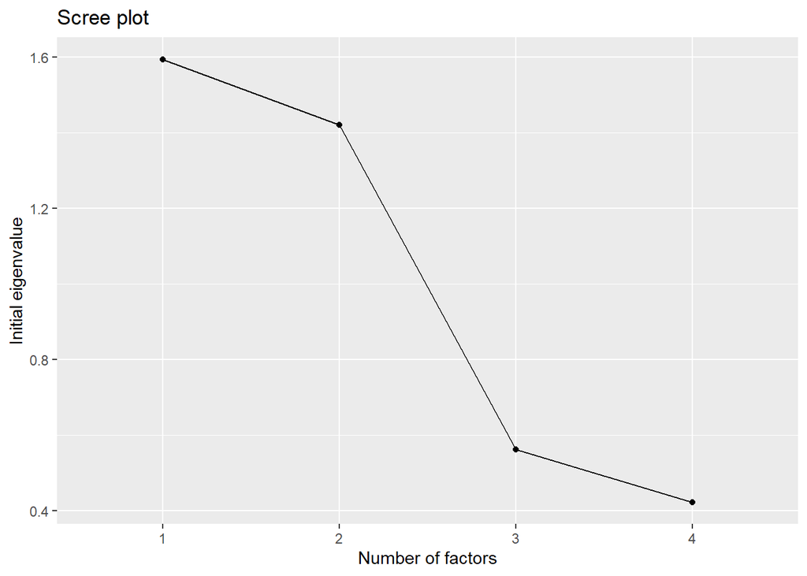

```r
fafitfree <- fa(PCADf, nfactors = ncol(PCADf), rotate = "none")
n_factors <- length(fafitfree$e.values)
scree <- data.frame(
  Factor_n = as.factor(1:n_factors),
  Eigenvalue = fafitfree$e.values)
ggplot(scree, aes(x = Factor_n, y = Eigenvalue, group = 1)) +
  geom_point() + geom_line() +
  xlab("Number of factors") +
  ylab("Initial eigenvalue") +
  labs(title = "Scree plot")
```

Видно, что хорошо определяются два фактора.

```r
parallel <- fa.parallel(PCADf)
```

[figure not shown]

```
## Parallel analysis suggests that the number of factors =  2  and the number of components =  2
```

Смотрим на график с треугольниками (факторный анализ) - также определяется 2 фактора.

Теперь проведем факторный анализ по корреляционной матрице (по умолчанию):

```r
fa.varimax <- fa(r = PCADf,
  nfactors = 2,
  fm = "minres",
  max.iter = 100,
  rotate = "varimax")
print(fa.varimax)
```

```
## Factor Analysis using method =  minres
## Call: fa(r = PCADf, nfactors = 2, rotate = "varimax", max.iter = 100,
##     fm = "minres")
## Standardized loadings (pattern matrix) based upon correlation matrix
##          MR1   MR2   h2   u2 com
## Active  0.81  0.05 0.66 0.34 1.0
## Rest    0.70 -0.11 0.50 0.50 1.1
## Wgt     0.02  0.84 0.71 0.29 1.0
## Hgt    -0.05  0.53 0.28 0.72 1.0
##
##                        MR1  MR2
## SS loadings           1.15 1.00
## Proportion Var        0.29 0.25
## Cumulative Var        0.29 0.54
## Proportion Explained  0.53 0.47
## Cumulative Proportion 0.53 1.00
##
## Mean item complexity =  1
## Test of the hypothesis that 2 factors are sufficient.
##
## The degrees of freedom for the null model are  6  and the objective function was  0.62 with Chi Square of  57.03
## The degrees of freedom for the model are -1  and the objective function was  0
##
## The root mean square of the residuals (RMSR) is  0
## The df corrected root mean square of the residuals is  NA
##
## The harmonic number of observations is  95 with the empirical chi square  0  with prob <  NA
## The total number of observations was  95  with Likelihood Chi Square =  0  with prob <  NA
##
## Tucker Lewis Index of factoring reliability =  1.12
## Fit based upon off diagonal values = 1
## Measures of factor score adequacy
##                                                    MR1  MR2
## Correlation of (regression) scores with factors   0.86 0.86
## Multiple R square of scores with factors          0.74 0.74
## Minimum correlation of possible factor scores     0.49 0.48
```

MR1 и MR2 - факторные нагрузки, видим, что первый фактор состоит в основном из признаков Active и Rest, а второй - из признаков Wgt и Hgt.

Посмотрим на даиграмму, иллюстрирующую то, из чего состоят найденные факторы (иллюстрация столбцов MR1 и MR2):

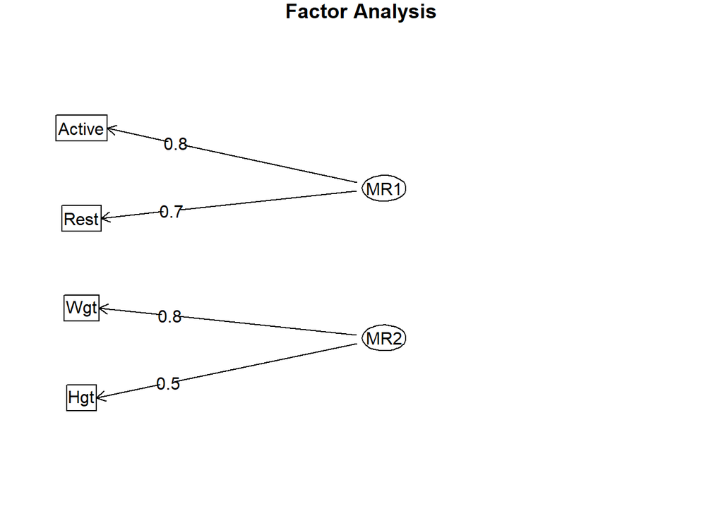

```r
fa.diagram(fa.varimax)
```

Видим, что первый скрытый фактор - определяет пульс человека, а второй - комплекцию человека.

Построим Biplots:

Для случая без поворота (изначально):

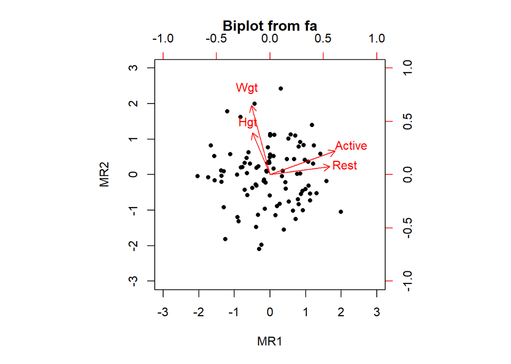

```r
fa.none <- fa(r = PCADf,
  nfactors = 2,
  fm = "minres",
  max.iter = 100,
  rotate = "none")

x <- list()
x$scores <- fa.none$scores
x$loadings <- fa.none$loadings
class(x) <- c('psych','fa')
biplot(x)
```

С поворотом:

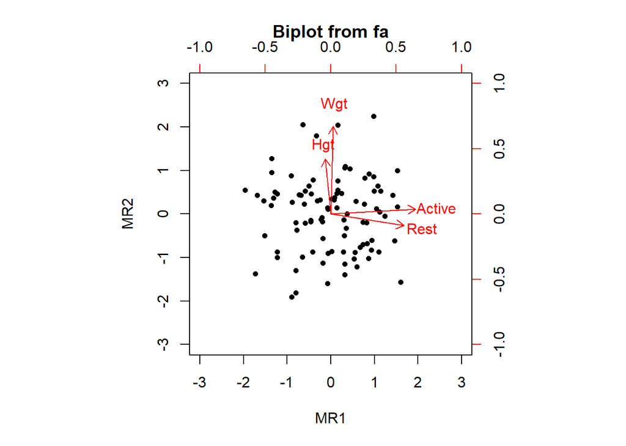

```r
x <- list()
x$scores <- fa.varimax$scores
x$loadings <- fa.varimax$loadings
class(x) <- c('psych','fa')
biplot(x)
```